# Lab 6

Hannah Stanfor

10/08/2021

## Instructions

1. Before beginning this assignment, rename the file by following these steps:
- From the Files tab in the bottom right RStudio pane, check the box for `lastname_firstname_lab_06.Rmd`. Then, click Rename.
- Replace lastname and firstname with your last and first name, followed by `_lab_06.Rmd`. Then click OK.
- (Alternatively, you can click File –> Save As. However, this creates a copy of the file, so after saving a new name, you’ll need to delete the original file `lastname_firstname_lab_06.Rmd`).
2. Enter your name for author at the top of this document (where it says `author: "Your Name"`).
3. If you’d like, use the visual markdown editor by clicking the top-right button of this document (the one that looks sort of like an A).
4. Read the introduction, and click on the link to take a look at the Nature paper that is references. Then, follow the directions to complete the problems below.

## Introduction

The GLOPNET database, originally [published in Nature by Wright et al. 2004](https://www.nature.com/articles/nature02403), is a plant trait dataset consisting of over 2548 plants reprsenting 2022 plant species from across the world (175 field sites total). The dataset includes **categorical** information, such as whether the species is deciduous or evergreen, biome information, etc., as well as **continuous** trait data, including leaf traits like leaf mass per area (LMA), leaf nitrogen concentration (Nmass, Narea), photosynthetic rate (Amass, Aarea), and much more. Many of the traits are expressed on a log10-scale, and are expressed relative to leaf dry mass (e.g. Nmass, Amass) or fresh leaf area (Narea, Aarea). The Wright et al. paper describes a global correlation of these plant traits that make up the so-called “worldwide leaf economics spectrum” (WLES). The WLES is an economic metaphor for thinking about plant carbon investment in building a leaf (“investment”) versus the photosynthetic output (“return on investment”). Plants can adopt a “fast” (i.e. “get-rich-quick”) strategy with cheap, disposable leaves with a short leaf lifespan (LL), low LMA, and high photosynthetic rate and nutrient concentration; alternatively, plants can adopt a “slow” strategy with more durable, “expensive”, longer-lasting leaves that have a long LL, high LMA, with lower photosynthetic rates and nutrient concentrations. In other words, the WLES suggests a trade-off between leaf productivity rate vs leaf durability.

## Problems

1. Use ggplot to visualize the relationship between logNmass and logAmass.
- Note that the dataset contains missing values for certain traits, so be sure to suppress the warning message by setting warning=FALSE in the R code chunk below.
- Alternatively: if you’d like to avoid typing this for every code chunk with a warning, you can set `knitr::opts_chunk$set(warning = FALSE)` in the `setup` chunk at the top of this document.
  - This will suppress warnings for all code chunks when knitting the document (you may still see a warning when previewing the code – that’s OK).

```
## Warning: Removed 1836 rows containing non-finite values (stat_smooth).
```

```
## Warning: Removed 1836 rows containing missing values (geom_point).
```

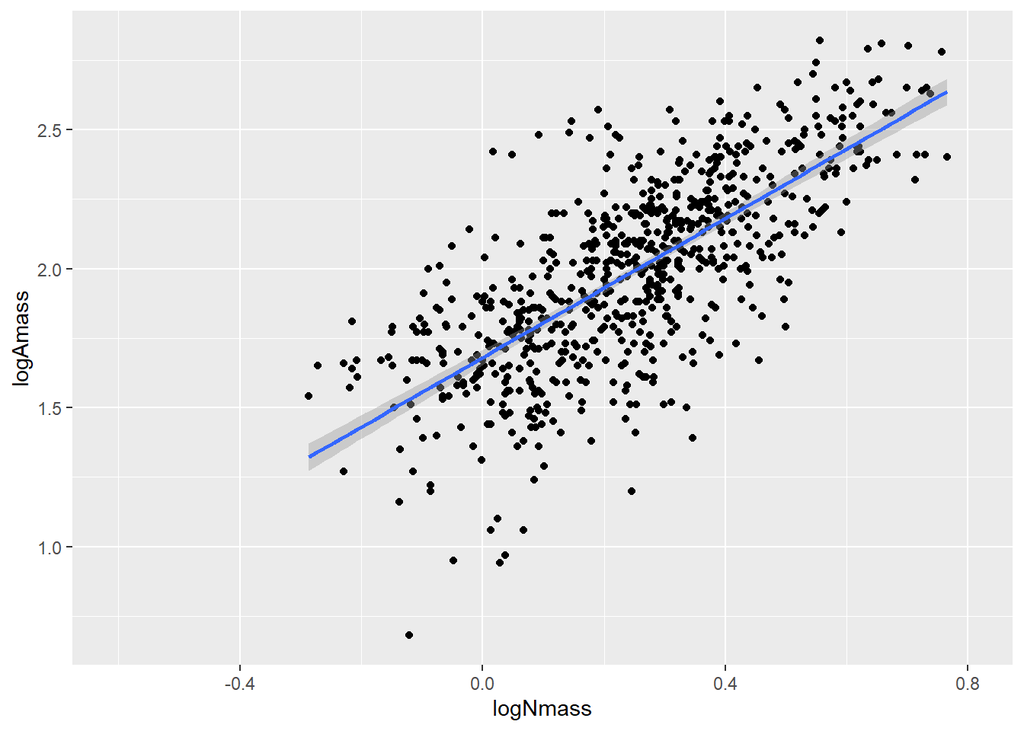

```r
library(ggplot2)
ggplot(dat, aes(logNmass, logAmass))+
  geom_point()+
  geom_smooth(method = lm)
```

2. Let’s avoid having to type the code from #1 over and over again. In the R code chunk below, copy and paste your code from number 1, but this time, store it in an R object. After storing the gpplot in an R object, on the next line, simply type the name of the R object to plot the figure again.
- You can choose the object name, but it’s a good idea to make it informative so your code is easier to read.
  - For instance, `Nmass_vs_Amas` would be an informative name.
  - On the other hand, when feeling lazy, I usually just say `g <-` for storing ggplots).
  - The output will appear the same regardless, but it’s *better* in general to use an informative name.

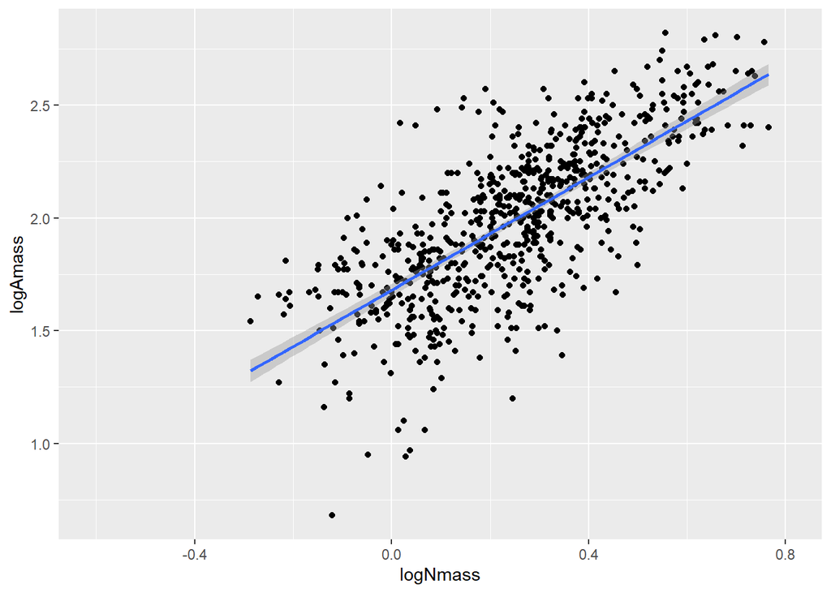

```r
library(ggplot2)
codetemplate <- ggplot(dat, aes(logNmass, logAmass))+
  geom_point()+
  geom_smooth(method = lm)
codetemplate
```

3. Re-plot the figure using your R object from #2, but this time, change the theme to something you like better than the default setting (which is `theme_gray()`).
- There are two ways of doing this.
- If you want the new theme to be permanent, you can overwrite the R object with the new theme, and then plot it
- If you’d prefer to only plt the new theme for #3 (i.e. if you happen to like the default `theme_gray()` best), you can simply type the R object name, then a plus sign, and then the theme function.

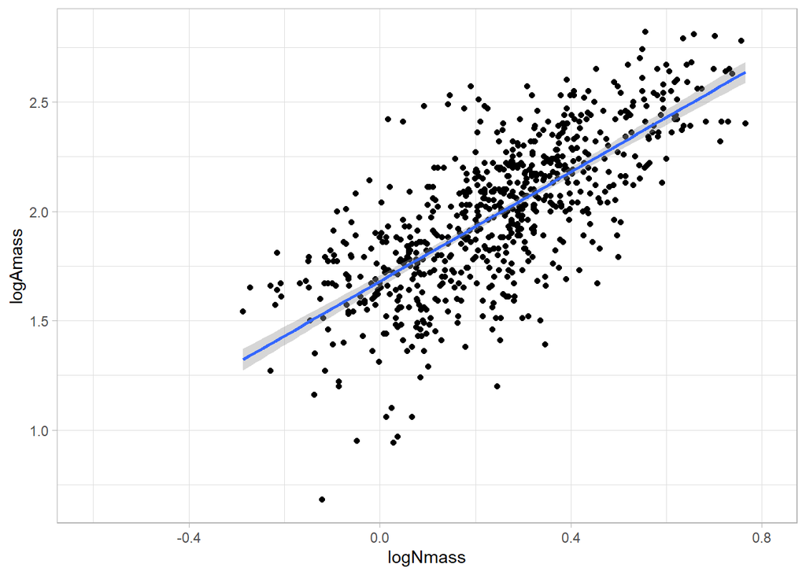

```r
codetemplate +
  theme_light()
```

4. Plot your figure, but this time, color-code the data points with the variable `decid_evergreen`.
- There are two ways of doing this.
- You can either copy and paste the code from #1, and add `color` as an argument to the `aes` function.
- Or you can type the name of your R object, then a plus sign, and then the `aes` function with `color` as an argument.

```r
plot1 <- ggplot(dat, aes(logNmass, logAmass, color = decid_evergreen))+
  geom_point()
```

5. Notice there are 3 colors in the #4 plot. The first color corresponds to `D` for deciduous, the second color corresponds to `E` for evergreen, and the third color correponds to missing data. Either the data was unavailable for that species, or the species was neither deciduous nor evergreen. **For this problem**:
- For every value of `dat$decid_evergreen` with an empty cell, replace it with the word `Other / Unavailable`.
  - This will require you to subset using a logical vector.
  - Specifically, you must whether a cell has missing data. For this, you can use the `is.na()` function. For example:
  - `is.na(dat$decid_evergreen)`
  - Overwrite the subset of `dat$decid_evergreen` where the values of `is.na(dat$decid_evergreen)` are `TRUE` with the word `Other`.
- Next, replace every instance of `E` with the word `Evergreen` and every instance of `D` with `Deciduous`.
- Now that you have successfully edited the `dat$decis_evergreen` column, you must update the `data` argument. Otherwise, your changes won’t be in the new plot.
- Example instructions: If your plot was named `g`, you would use the code `g$data <- dat`.
- Finally, copy and paste the code from #4 to re-plot the figure. Now, the three colors in the legend should be listed as `Deciduous`, `Evergreen`, and `Other / Unavailable`.

```r
dat$decid_evergreen[is.na(dat$decid_evergreen)] <- "Other/Unavailable"
dat$decid_evergreen[dat$decid_evergreen == "E"] <- "Evergreen"
dat$decid_evergreen[dat$decid_evergreen == "D"] <- "Deciduous"
dat$decid_evergreen
```

[output not shown]

[output cut: 835 more lines]

```r
plot1$data <- dat
```

6. Paste the code from #4 again, and use the labs function to replace `decid_evergreen` with `Plant Type`. Also, replace `logNmass` with `log-10 Nmass` and replace `logAmass` with `log-10 Amass`. Add a title that says `Worldwide Leaf Economics Spectrum`

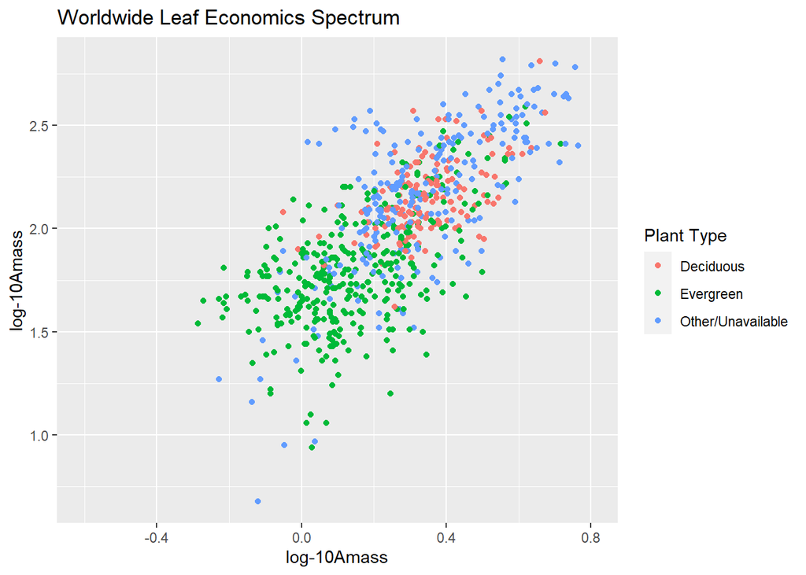

```r
plot1 <- ggplot(dat, aes(logNmass, logAmass, color = decid_evergreen))+
  geom_point()+
  labs(x = "log-10Amass", y = "log-10Amass", color = "Plant Type", title = "Worldwide Leaf Economics Spectrum")
plot1
```

7. Make a new plot, and store it in an R object (with the name of your choice).
- Color-code the plants according to the variable `C3C4`.
  - Before plotting, you’ll need to replace the NA values in `C3C4` with `Other / Unavailable`, as you did in #5.
- Plot decid_evergreen using shape (instead of color).
- This time, plot the relationship between `logNmass` and `logLL` (leaf lifespan).
- Edit the x-axis label and y-axis label appropriately.
- Increase the size of the points in the scatterplot.

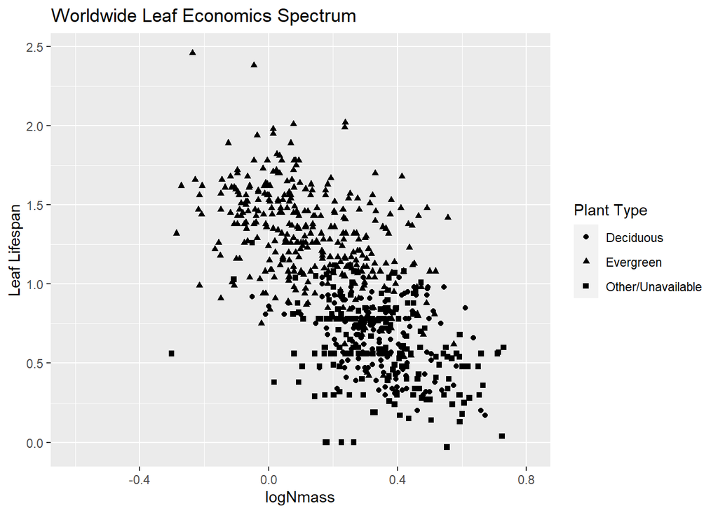

```r
dat$C3C4[is.na(dat$C3C4)] <- "Other/Unavailable"
newplot <- ggplot(dat, aes(logNmass,logLL, shape = decid_evergreen))+
  geom_point(size = 1.5)+
  labs(x = "logNmass", y = "Leaf Lifespan", shape = "Plant Type", title ="Worldwide Leaf Economics Spectrum")
newplot
```

8. Make a new plot. This time, plot the relationship between `logLMA` and `logAmass`. Set the color of the points in the scatterplot to `"grey"`. Add a `geom_smooth` to the plot, with the lines color-coded by `BIOME`.

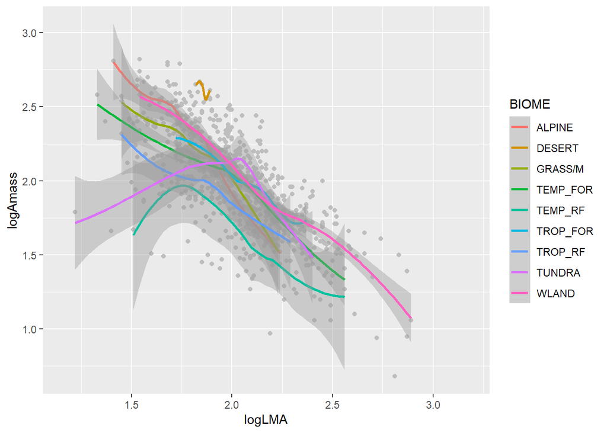

```r
newplot2 <- ggplot(dat, aes(logLMA,logAmass, color = BIOME))+
  geom_point(color = "grey")+
  geom_smooth()
newplot2
```

9. When you are finished, save the document, knit the document, commit your changes, and push the changes to your repository. Be sure to add me as as a collaborator on GitHub, and then submit the URL to your reposiotry in Webcourses for the Lab 6 assignment.